# Introduction

## Recap last session

- Functions
- Packages & modules
- The scipy universe
  - numpy
  - matplotlib

## Contents of this session

- Basics primer
  - String literals
  - Advanced for-loops
  - File input/output
- The scipy universe: pandas
- Image processing session

Questions: please interrupt :-)

Format: live coding in Spyder  
Use Spyder or Jupyter Notebook

# Basics primer

## String literals

https://docs.python.org/3/reference/lexical_analysis.html#string-and-bytes-literals

The character `\` is used to escape characters that otherwise have a special meaning.

| Escape Sequence | Meaning |
| --- | --- |
| `\\` | Backslash (\) |
| `\'` | Single quote (') |
| `\"` | Double quote (") |
| `\n` | ASCII Linefeed (LF) |
| `\r` | ASCII Carriage Return (CR) |
| `\t` | ASCII Horizontal Tab (TAB) |

New lines on Windows: `"\r\n"`  
New lines on Linux/Mac/**Python**: `"\n"`

## Advanced for-loops

Assume you want to print both the position and the value of list elements.

```python
l = ["Hello", "beautiful", "World"]
```

```python
i = 0
for x in l:
    print(i, x)
    i += 1
```

```
0 Hello
1 beautiful
2 World
```

```python
for i in range(len(l)):
    print(i, l[i])
```

```
0 Hello
1 beautiful
2 World
```

```python
# enumerate: generator that yields tuples (index, element)
for i, x in enumerate(l):
    print(i, x)
```

```
0 Hello
1 beautiful
2 World
```

Assume you want to iterate over two or more lists at the same time.

```python
l1 = [1, 2, 3, 4]
l2 = ["one", "two", "three", "four"]
l3 = ["eins", "zwei", "drei", "vier"]
```

```python
# zip: yields a tuple of elements from the passed iterables, by position
for x1, x2, x3 in zip(l1, l2, l3):
    print(x1, x2, x3)
```

```
1 one eins
2 two zwei
3 three drei
4 four vier
```

## File input/output

```python
file_obj = open('../Data/iris.csv', 'r')
file_contents = file_obj.read()
file_obj.close()  # don't forget this; still unsafe!

print(file_contents[:100])  # first 100 characters
```

```
Sepal.Length,Sepal.Width,Petal.Length,Petal.Width,Species
5.1,3.5,1.4,0.2,setosa
4.9,3,1.4,0.2,setos
```

```python
with open('../Data/iris.csv', 'r') as file_obj:  # context manager
    file_contents = file_obj.read()

print(file_contents[:100])  # first 100 characters
```

```
Sepal.Length,Sepal.Width,Petal.Length,Petal.Width,Species
5.1,3.5,1.4,0.2,setosa
4.9,3,1.4,0.2,setos
```

### Methods of file objects

Note: file object remember the current position in the file

| Method | Description |
| --- | --- |
| `read()` | Reads the file and returns its content as a string |
| `read(n)` | Same as `read()`, but reads at most `n` characters |
| `readline()` | Reads a single line (terminated by `"\n"`) of the file |
| `readlines()` | Reads all lines of the file and returns them as a list |
| `write(s)` | Writes the string `s` to the file |

### Exercise

Write a function that reads a CSV file into a dictionary.

Dictionary keys: column names (string)  
Dictionary values: lists of column values (strings, for now)

```python
def read_csv(file):
    d = {}
    with open(file, 'r') as f:
        header = f.readline().strip()
        columns = header.split(',')
        for column in columns:
            d[column] = []
        for line in f:  # iterate over remaining lines
            line_values = line.strip().split(',')
            for column, line_value in zip(columns, line_values):
                d[column].append(line_value)
    return d
```

```python
iris = read_csv('../Data/iris.csv')  # note: strings only!
print(iris['Species'][:60])  # species of the first 60 rows
```

```
['setosa', 'setosa', 'setosa', 'setosa', 'setosa', 'setosa', 'setosa', 'setosa', 'setosa', 'setosa', 'setosa', 'setosa', 'setosa', 'setosa', 'setosa', 'setosa', 'setosa', 'setosa', 'setosa', 'setosa', 'setosa', 'setosa', 'setosa', 'setosa', 'setosa', 'setosa', 'setosa', 'setosa', 'setosa', 'setosa',…
```

### Exercise

Write a function that writes a dictionary into a CSV file.

Dictionary keys: column names (string)  
Dictionary values: lists of column values (strings, for now)

```python
def write_csv(file, d, line_ending='\n'):
    with open(file, 'w') as f:
        columns = list(d.keys())
        header = ','.join(columns) + line_ending
        f.write(header)
        for i in range(len(d[columns[0]])):
            line_values = []
            for column in columns:
                line_values.append(d[column][i])
            line = ','.join(line_values) + line_ending
            f.write(line)
```

```python
iris = read_csv('../Data/iris.csv')
write_csv('iris_copy.csv', iris)
```

# The pandas package

Copied from https://pandas.pydata.org (part of the scipy ecosystem):

> pandas is a fast, powerful, flexible and easy to use open source data analysis and manipulation tool, built on top of the Python programming language.

The pandas package is particularly well suited for analyzing tabular data.  
For R users, pandas provides everything that R's data.frame provides (and more).  
https://pandas.pydata.org/docs/getting_started/comparison/comparison_with_r.html

Excellent documentation & tutorials: https://pandas.pydata.org/docs/  
The pandas package comes pre-installed with Anaconda for Python 3.7.

Disclaimer: This introduction is loosely based on [10 minutes to pandas](https://pandas.pydata.org/docs/getting_started/10min.html).

```python
import numpy as np  # pandas is built on top of numpy
import pandas as pd  # by convention, pandas is imported as pd
```

## Basic data structures (1D)

```python
s = pd.Series([1, 3, 5, np.nan, 6, 8])
print(s)
```

```
0    1.0
1    3.0
2    5.0
3    NaN
4    6.0
5    8.0
dtype: float64
```

```python
print(s.index)  # defaults to RangeIndex (0, 1, 2, ..., n)
```

```
RangeIndex(start=0, stop=6, step=1)
```

```python
print(s.values)  # type: one-dimensional np.ndarray
```

```
[ 1.  3.  5. nan  6.  8.]
```

## Basic data structures (2D)

```python
df = pd.DataFrame({
    'odd': [1, 3, 5, 7, 9],  # list will be converted to pd.Series
    'even': [2, 4, 6, 8, 10]  # list will be converted to pd.Series
})
print(df)
```

```
   odd  even
0    1     2
1    3     4
2    5     6
3    7     8
4    9    10
```

```python
print(df.columns)
```

```
Index(['odd', 'even'], dtype='object')
```

```python
print(df.index)  # defaults to RangeIndex (0, 1, 2, ..., n)
```

```
RangeIndex(start=0, stop=5, step=1)
```

```python
print(df.values)  # type: two-dimensional np.ndarray
```

```
[[ 1  2]
 [ 3  4]
 [ 5  6]
 [ 7  8]
 [ 9 10]]
```

## Fetching data

```python
# 2019-nCoV Data Repository by Johns Hopkins CSSE
confirmed_url = 'https://raw.githubusercontent.com/CSSEGISandData/COVID-19/master/csse_covid_19_data/csse_covid_19_time_series/time_series_covid19_confirmed_global.csv'
recovered_url = 'https://raw.githubusercontent.com/CSSEGISandData/COVID-19/master/csse_covid_19_data/csse_covid_19_time_series/time_series_covid19_recovered_global.csv'
deaths_url = 'https://raw.githubusercontent.com/CSSEGISandData/COVID-19/master/csse_covid_19_data/csse_covid_19_time_series/time_series_covid19_deaths_global.csv'

def fetch_covid(url, value_name):
    df = pd.read_csv(url).fillna('')  # groupby drops np.nan keys!
    groups = df.groupby(['Country/Region', 'Province/State', 'Lat', 'Long'])
    def melt_group_dates(group):
        group = group.drop(columns=groups.keys)
        group = group.melt(var_name='Date', value_name=value_name)
        group['Date'] = pd.to_datetime(group['Date'])
        return group.set_index('Date')
    return groups.apply(melt_group_dates).reset_index()

covid_cases = fetch_covid(confirmed_url, 'Confirmed')
covid_cases = pd.merge(covid_cases, fetch_covid(recovered_url, 'Recovered'))
covid_cases = pd.merge(covid_cases, fetch_covid(deaths_url, 'Deaths'))
covid_cases.to_csv('../Data/covid19.csv', index=False)
```

## Reading/writing data

Note: from here on, assuming interactive mode ("automatic print")

```python
# iris = read_csv('../Data/iris.csv')
# df = pd.DataFrame(iris)

covid_cases = pd.read_csv('../Data/covid19.csv')  # read_excel, read_sql, ...
covid_cases.head(10)  # first ten rows
```

|  | Country/Region | Province/State | Lat | Long | Date | Confirmed | Recovered | Deaths |
| --- | --- | --- | --- | --- | --- | --- | --- | --- |
| 0 | Afghanistan | NaN | 33.0 | 65.0 | 2020-01-22 | 0 | 0 | 0 |
| 1 | Afghanistan | NaN | 33.0 | 65.0 | 2020-01-23 | 0 | 0 | 0 |
| 2 | Afghanistan | NaN | 33.0 | 65.0 | 2020-01-24 | 0 | 0 | 0 |
| 3 | Afghanistan | NaN | 33.0 | 65.0 | 2020-01-25 | 0 | 0 | 0 |
| 4 | Afghanistan | NaN | 33.0 | 65.0 | 2020-01-26 | 0 | 0 | 0 |
| 5 | Afghanistan | NaN | 33.0 | 65.0 | 2020-01-27 | 0 | 0 | 0 |
| 6 | Afghanistan | NaN | 33.0 | 65.0 | 2020-01-28 | 0 | 0 | 0 |
| 7 | Afghanistan | NaN | 33.0 | 65.0 | 2020-01-29 | 0 | 0 | 0 |
| 8 | Afghanistan | NaN | 33.0 | 65.0 | 2020-01-30 | 0 | 0 | 0 |
| 9 | Afghanistan | NaN | 33.0 | 65.0 | 2020-01-31 | 0 | 0 | 0 |

```python
covid_cases.to_csv('covid_copy.csv', index=False)  # to_markdown, to_latex, ...
```

## Sorting

```python
covid_cases.sort_values( # not in-place --> covid_cases remains unchanged
    ['Country/Region', 'Province/State', 'Date'],
    ascending=[True, True, False]
)
```

|  | Country/Region | Province/State | Lat | Long | Date | Confirmed | Recovered | Deaths |
| --- | --- | --- | --- | --- | --- | --- | --- | --- |
| 75 | Afghanistan | NaN | 33.0 | 65.0 | 2020-04-06 | 367 | 18 | 11 |
| 74 | Afghanistan | NaN | 33.0 | 65.0 | 2020-04-05 | 349 | 15 | 7 |
| 73 | Afghanistan | NaN | 33.0 | 65.0 | 2020-04-04 | 299 | 10 | 7 |
| 72 | Afghanistan | NaN | 33.0 | 65.0 | 2020-04-03 | 281 | 10 | 6 |
| 71 | Afghanistan | NaN | 33.0 | 65.0 | 2020-04-02 | 273 | 10 | 6 |
| ... | ... | ... | ... | ... | ... | ... | ... | ... |
| 18548 | Zimbabwe | NaN | -20.0 | 30.0 | 2020-01-26 | 0 | 0 | 0 |
| 18547 | Zimbabwe | NaN | -20.0 | 30.0 | 2020-01-25 | 0 | 0 | 0 |
| 18546 | Zimbabwe | NaN | -20.0 | 30.0 | 2020-01-24 | 0 | 0 | 0 |
| 18545 | Zimbabwe | NaN | -20.0 | 30.0 | 2020-01-23 | 0 | 0 | 0 |
| 18544 | Zimbabwe | NaN | -20.0 | 30.0 | 2020-01-22 | 0 | 0 | 0 |

18620 rows × 8 columns

## Indexing

https://pandas.pydata.org/pandas-docs/stable/user_guide/indexing.html

```python
covid_cases[5:10]  # slice --> select rows with position in [5, 10)
```

|  | Country/Region | Province/State | Lat | Long | Date | Confirmed | Recovered | Deaths |
| --- | --- | --- | --- | --- | --- | --- | --- | --- |
| 5 | Afghanistan | NaN | 33.0 | 65.0 | 2020-01-27 | 0 | 0 | 0 |
| 6 | Afghanistan | NaN | 33.0 | 65.0 | 2020-01-28 | 0 | 0 | 0 |
| 7 | Afghanistan | NaN | 33.0 | 65.0 | 2020-01-29 | 0 | 0 | 0 |
| 8 | Afghanistan | NaN | 33.0 | 65.0 | 2020-01-30 | 0 | 0 | 0 |
| 9 | Afghanistan | NaN | 33.0 | 65.0 | 2020-01-31 | 0 | 0 | 0 |

```python
covid_cases.Date  # attribute --> select the Date column
```

```
0        2020-01-22
1        2020-01-23
2        2020-01-24
3        2020-01-25
4        2020-01-26
            ...
18615    2020-04-02
18616    2020-04-03
18617    2020-04-04
18618    2020-04-05
18619    2020-04-06
Name: Date, Length: 18620, dtype: object
```

```python
covid_cases['Country/Region']  # label --> select the Country/Region column
```

```
0        Afghanistan
1        Afghanistan
2        Afghanistan
3        Afghanistan
4        Afghanistan
            ...
18615       Zimbabwe
18616       Zimbabwe
18617       Zimbabwe
18618       Zimbabwe
18619       Zimbabwe
Name: Country/Region, Length: 18620, dtype: object
```

```python
# list of labels --> select the specified columns
covid_cases[['Country/Region', 'Province/State', 'Date', 'Confirmed']]
```

|  | Country/Region | Province/State | Date | Confirmed |
| --- | --- | --- | --- | --- |
| 0 | Afghanistan | NaN | 2020-01-22 | 0 |
| 1 | Afghanistan | NaN | 2020-01-23 | 0 |
| 2 | Afghanistan | NaN | 2020-01-24 | 0 |
| 3 | Afghanistan | NaN | 2020-01-25 | 0 |
| 4 | Afghanistan | NaN | 2020-01-26 | 0 |
| ... | ... | ... | ... | ... |
| 18615 | Zimbabwe | NaN | 2020-04-02 | 9 |
| 18616 | Zimbabwe | NaN | 2020-04-03 | 9 |
| 18617 | Zimbabwe | NaN | 2020-04-04 | 9 |
| 18618 | Zimbabwe | NaN | 2020-04-05 | 9 |
| 18619 | Zimbabwe | NaN | 2020-04-06 | 10 |

18620 rows × 4 columns

```python
# mask --> select rows with Confirmed > 500
covid_cases[covid_cases['Confirmed'] > 500]
```

|  | Country/Region | Province/State | Lat | Long | Date | Confirmed | Recovered | Deaths |
| --- | --- | --- | --- | --- | --- | --- | --- | --- |
| 219 | Algeria | NaN | 28.0339 | 1.6596 | 2020-03-29 | 511 | 31 | 31 |
| 220 | Algeria | NaN | 28.0339 | 1.6596 | 2020-03-30 | 584 | 37 | 35 |
| 221 | Algeria | NaN | 28.0339 | 1.6596 | 2020-03-31 | 716 | 46 | 44 |
| 222 | Algeria | NaN | 28.0339 | 1.6596 | 2020-04-01 | 847 | 61 | 58 |
| 223 | Algeria | NaN | 28.0339 | 1.6596 | 2020-04-02 | 986 | 61 | 86 |
| ... | ... | ... | ... | ... | ... | ... | ... | ... |
| 17247 | United Kingdom | NaN | 55.3781 | -3.4360 | 2020-04-02 | 33718 | 135 | 2921 |
| 17248 | United Kingdom | NaN | 55.3781 | -3.4360 | 2020-04-03 | 38168 | 135 | 3605 |
| 17249 | United Kingdom | NaN | 55.3781 | -3.4360 | 2020-04-04 | 41903 | 135 | 4313 |
| 17250 | United Kingdom | NaN | 55.3781 | -3.4360 | 2020-04-05 | 47806 | 135 | 4934 |
| 17251 | United Kingdom | NaN | 55.3781 | -3.4360 | 2020-04-06 | 51608 | 135 | 5373 |

1949 rows × 8 columns

```python
# for multiple conditions, use binary bitwise operators: ~ & |
# docs.python.org/3.7/reference/expressions.html#binary-bitwise-operations

country_mask = covid_cases['Country/Region'].isin(['China', 'France'])
covid_cases[(covid_cases['Confirmed'] > 500) & country_mask]
```

|  | Country/Region | Province/State | Lat | Long | Date | Confirmed | Recovered | Deaths |
| --- | --- | --- | --- | --- | --- | --- | --- | --- |
| 3206 | China | Anhui | 31.8257 | 117.2264 | 2020-02-05 | 530 | 23 | 0 |
| 3207 | China | Anhui | 31.8257 | 117.2264 | 2020-02-06 | 591 | 34 | 0 |
| 3208 | China | Anhui | 31.8257 | 117.2264 | 2020-02-07 | 665 | 47 | 0 |
| 3209 | China | Anhui | 31.8257 | 117.2264 | 2020-02-08 | 733 | 59 | 0 |
| 3210 | China | Anhui | 31.8257 | 117.2264 | 2020-02-09 | 779 | 72 | 1 |
| ... | ... | ... | ... | ... | ... | ... | ... | ... |
| 7747 | France | NaN | 46.2276 | 2.2137 | 2020-04-02 | 59105 | 12428 | 5387 |
| 7748 | France | NaN | 46.2276 | 2.2137 | 2020-04-03 | 64338 | 14008 | 6507 |
| 7749 | France | NaN | 46.2276 | 2.2137 | 2020-04-04 | 89953 | 15438 | 7560 |
| 7750 | France | NaN | 46.2276 | 2.2137 | 2020-04-05 | 92839 | 16183 | 8078 |
| 7751 | France | NaN | 46.2276 | 2.2137 | 2020-04-06 | 98010 | 17250 | 8911 |

743 rows × 8 columns

### Explicitly select by label

```python
# column label --> Series
covid_cases.loc[[0, 1, 2], 'Country/Region']
```

```
0    Afghanistan
1    Afghanistan
2    Afghanistan
Name: Country/Region, dtype: object
```

```python
# list of column labels --> DataFrame
covid_cases.loc[[0, 1, 2], ['Country/Region', 'Date']]
```

|  | Country/Region | Date |
| --- | --- | --- |
| 0 | Afghanistan | 2020-01-22 |
| 1 | Afghanistan | 2020-01-23 |
| 2 | Afghanistan | 2020-01-24 |

Attention: avoid slicing (i.e., indexing using ranges) when selecting by label using loc!  
https://pandas.pydata.org/docs/user_guide/indexing.html#indexing-slicing-with-labels

### Explicitly select by position

```python
covid_cases.iloc[:5, :]  # first five rows
```

|  | Country/Region | Province/State | Lat | Long | Date | Confirmed | Recovered | Deaths |
| --- | --- | --- | --- | --- | --- | --- | --- | --- |
| 0 | Afghanistan | NaN | 33.0 | 65.0 | 2020-01-22 | 0 | 0 | 0 |
| 1 | Afghanistan | NaN | 33.0 | 65.0 | 2020-01-23 | 0 | 0 | 0 |
| 2 | Afghanistan | NaN | 33.0 | 65.0 | 2020-01-24 | 0 | 0 | 0 |
| 3 | Afghanistan | NaN | 33.0 | 65.0 | 2020-01-25 | 0 | 0 | 0 |
| 4 | Afghanistan | NaN | 33.0 | 65.0 | 2020-01-26 | 0 | 0 | 0 |

```python
covid_cases.iloc[:5, -3:]  # first five rows, last three columns
```

|  | Confirmed | Recovered | Deaths |
| --- | --- | --- | --- |
| 0 | 0 | 0 | 0 |
| 1 | 0 | 0 | 0 |
| 2 | 0 | 0 | 0 |
| 3 | 0 | 0 | 0 |
| 4 | 0 | 0 | 0 |

### Setting values

```python
df = covid_cases.copy()
```

```python
df['HasDeaths'] = False  # adds a new column
df.loc[df['Deaths'] > 0, 'HasDeaths'] = True
df.head()
```

|  | Country/Region | Province/State | Lat | Long | Date | Confirmed | Recovered | Deaths | HasDeaths |
| --- | --- | --- | --- | --- | --- | --- | --- | --- | --- |
| 0 | Afghanistan | NaN | 33.0 | 65.0 | 2020-01-22 | 0 | 0 | 0 | False |
| 1 | Afghanistan | NaN | 33.0 | 65.0 | 2020-01-23 | 0 | 0 | 0 | False |
| 2 | Afghanistan | NaN | 33.0 | 65.0 | 2020-01-24 | 0 | 0 | 0 | False |
| 3 | Afghanistan | NaN | 33.0 | 65.0 | 2020-01-25 | 0 | 0 | 0 | False |
| 4 | Afghanistan | NaN | 33.0 | 65.0 | 2020-01-26 | 0 | 0 | 0 | False |

### Indexing cheat sheet

Recommendation: primarily use `.loc` and `.iloc` (more explicit)  
For indexing on Series (similar), primarily use `s[x]` (index by position/mask)

| Method | Description & index arguments |
| --- | --- |
| `df.x` | Index by column *label* (only for valid column names) |
| `df[x]` | Mixed indexing **Slices**: index by row *position* **Strings/Lists**: index by column *label(s)* **Boolean arrays**: index by row mask |
| `df.loc[x, y]` | Selection by label **(Lists of) labels**: row/column *label(s)*, e.g. `123` `"Date"` **Boolean arrays**, e.g. `np.ones(nrows, dtype=bool)` **Slices**, e.g. `0:5` unexpected behavior in some cases --> … |
| `df.iloc[x, y]` | Selection by position **(Lists of) integers**: row/column *position(s)*, e.g. `0`, `-1` **Boolean arrays**, e.g. `np.ones(ncols, dtype=bool)` **Slices**, e.g. `0:5`, `:` (use "empty" slices to select … |
| `df.at[x, y]` `df.iat[x, y]` | Similar to `.loc` and `.iloc`, but for selecting single values |

## Descriptive statistics

https://pandas.pydata.org/docs/getting_started/basics.html#descriptive-statistics

```python
covid_cases.describe()
```

|  | Lat | Long | Confirmed | Recovered | Deaths |
| --- | --- | --- | --- | --- | --- |
| count | 18620.000000 | 18620.000000 | 18620.000000 | 18620.000000 | 18620.000000 |
| mean | 20.135504 | 27.923648 | 930.726423 | 240.687594 | 42.926799 |
| std | 24.269688 | 67.130318 | 8595.317656 | 2730.060103 | 508.084759 |
| min | -51.796300 | -102.552800 | 0.000000 | 0.000000 | 0.000000 |
| 25% | 6.877000 | -8.224500 | 0.000000 | 0.000000 | 0.000000 |
| 50% | 21.916200 | 21.758700 | 1.000000 | 0.000000 | 0.000000 |
| 75% | 39.399900 | 88.092400 | 71.000000 | 3.000000 | 0.000000 |
| max | 71.706900 | 178.065000 | 366667.000000 | 64014.000000 | 16523.000000 |

```python
covid_cases.sum()  # mean, median, std, min, max, quantile, value_counts, ...
```

```
Country/Region    AfghanistanAfghanistanAfghanistanAfghanistanAf...
Lat                                                          374923
Long                                                         519938
Date              2020-01-222020-01-232020-01-242020-01-252020-0...
Confirmed                                                  17330126
Recovered                                                   4481603
Deaths                                                       799297
dtype: object
```

## Grouping

```python
countries = ['Austria', 'Germany', 'Switzerland', 'United Kingdom', 'US']
df = covid_cases.loc[covid_cases['Country/Region'].isin(countries), :]
```

```python
for country_region, g in df.groupby('Country/Region'):
    max_date = g['Date'].max()
    confirmed = g.loc[g['Date'] == max_date, 'Confirmed'].sum()
    recovered = g.loc[g['Date'] == max_date, 'Recovered'].sum()
    deaths = g.loc[g['Date'] == max_date, 'Deaths'].sum()
    print(max_date, confirmed, recovered, deaths, country_region, sep='\t')
```

```
2020-04-06	12297	3463	220	Austria
2020-04-06	103374	28700	1810	Germany
2020-04-06	21657	8056	765	Switzerland
2020-04-06	366667	19581	10783	US
2020-04-06	52279	287	5385	United Kingdom
```

## Merging

SQL-type joins

```python
df_confirmed = fetch_covid(confirmed_url, 'Confirmed')
df_recovered = fetch_covid(recovered_url, 'Recovered')
```

```python
pd.merge(df_confirmed, df_recovered)
```

|  | Country/Region | Province/State | Lat | Long | Date | Confirmed | Recovered |
| --- | --- | --- | --- | --- | --- | --- | --- |
| 0 | Afghanistan |  | 33.0 | 65.0 | 2020-01-22 | 0 | 0 |
| 1 | Afghanistan |  | 33.0 | 65.0 | 2020-01-23 | 0 | 0 |
| 2 | Afghanistan |  | 33.0 | 65.0 | 2020-01-24 | 0 | 0 |
| 3 | Afghanistan |  | 33.0 | 65.0 | 2020-01-25 | 0 | 0 |
| 4 | Afghanistan |  | 33.0 | 65.0 | 2020-01-26 | 0 | 0 |
| ... | ... | ... | ... | ... | ... | ... | ... |
| 18615 | Zimbabwe |  | -20.0 | 30.0 | 2020-04-02 | 9 | 0 |
| 18616 | Zimbabwe |  | -20.0 | 30.0 | 2020-04-03 | 9 | 0 |
| 18617 | Zimbabwe |  | -20.0 | 30.0 | 2020-04-04 | 9 | 0 |
| 18618 | Zimbabwe |  | -20.0 | 30.0 | 2020-04-05 | 9 | 0 |
| 18619 | Zimbabwe |  | -20.0 | 30.0 | 2020-04-06 | 10 | 0 |

18620 rows × 7 columns

## Concatenation

```python
df_china = covid_cases.loc[covid_cases['Country/Region'] == 'China', :]
df_france = covid_cases.loc[covid_cases['Country/Region'] == 'France', :]
```

```python
pd.concat([df_china, df_france])
```

|  | Country/Region | Province/State | Lat | Long | Date | Confirmed | Recovered | Deaths |
| --- | --- | --- | --- | --- | --- | --- | --- | --- |
| 3192 | China | Anhui | 31.8257 | 117.2264 | 2020-01-22 | 1 | 0 | 0 |
| 3193 | China | Anhui | 31.8257 | 117.2264 | 2020-01-23 | 9 | 0 | 0 |
| 3194 | China | Anhui | 31.8257 | 117.2264 | 2020-01-24 | 15 | 0 | 0 |
| 3195 | China | Anhui | 31.8257 | 117.2264 | 2020-01-25 | 39 | 0 | 0 |
| 3196 | China | Anhui | 31.8257 | 117.2264 | 2020-01-26 | 60 | 0 | 0 |
| ... | ... | ... | ... | ... | ... | ... | ... | ... |
| 8507 | France | St Martin | 18.0708 | -63.0501 | 2020-04-02 | 22 | 2 | 1 |
| 8508 | France | St Martin | 18.0708 | -63.0501 | 2020-04-03 | 22 | 2 | 1 |
| 8509 | France | St Martin | 18.0708 | -63.0501 | 2020-04-04 | 24 | 5 | 2 |
| 8510 | France | St Martin | 18.0708 | -63.0501 | 2020-04-05 | 32 | 7 | 2 |
| 8511 | France | St Martin | 18.0708 | -63.0501 | 2020-04-06 | 32 | 7 | 2 |

3344 rows × 8 columns

## Plotting examples

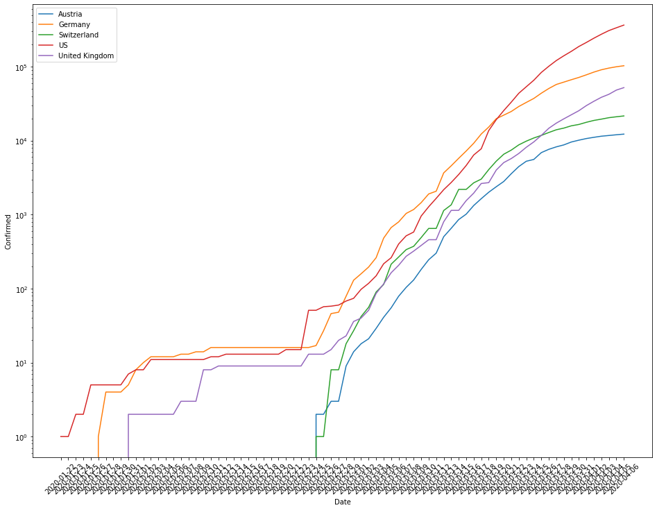

```python
import matplotlib.pyplot as plt

case_type = 'Confirmed'
countries = ['Austria', 'Germany', 'Switzerland', 'United Kingdom', 'US']

def plot_covid_cases(df, case_type, countries):
    df = df.loc[df['Country/Region'].isin(countries), :]
    for country, g in df.groupby('Country/Region'):
        cases_by_day = g.groupby('Date')[case_type].sum()
        plt.plot(cases_by_day.index, cases_by_day.values, label=country)

plt.figure(figsize=(16, 12))
plot_covid_cases(covid_cases, case_type, countries)
plt.yscale('log')
plt.xlabel('Date')
plt.ylabel(case_type)
plt.xticks(rotation=45)
plt.legend()
plt.show()
```

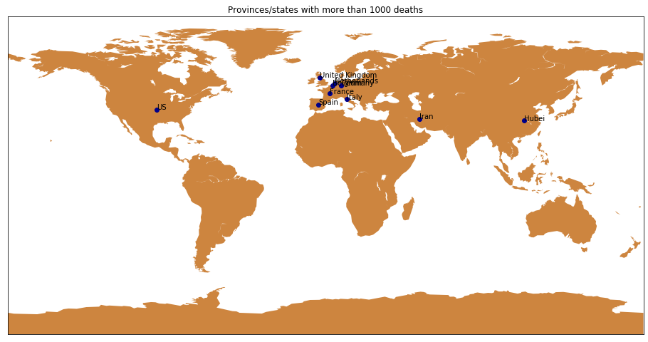

```python
import matplotlib.pyplot as plt
from mpl_toolkits.basemap import Basemap

case_thres = 1000
case_type = 'Deaths'

def plot_covid_map(df, case_type, case_thres=1000):
    m = Basemap(projection='cyl')
    m.fillcontinents(color='peru')
    groupby_columns = ['Country/Region', 'Province/State', 'Lat', 'Long']
    for k, g in df.fillna('').groupby(groupby_columns):
        country_region, province_state, lat, long = k
        num_cases = g.loc[g['Date'] == g['Date'].max(), case_type].sum()
        if num_cases > case_thres:
            x, y = m(long, lat)
            p = m.plot(x, y, 'o', color='darkblue')
            plt.text(x, y, province_state or country_region)

plt.figure(figsize=(16, 12))
plot_covid_map(covid_cases, case_type, case_thres)
plt.title(f'Provinces/states with more than {case_thres} {case_type.lower()}')
plt.show()
```

# Image processing session

Plan:

1. Load data
2. Show image
3. Quantify cells
4. Single-cell analysis

Prerequisite: `tifffile` package installed

```python
import tifffile
import matplotlib.pyplot as plt
import numpy as np
import pandas as pd
```

## Load data

```python
img_file_path = '../Data/jackson_fischer_nature_2020/BaselTMA_SP41_15.475kx12.665ky_10000x8500_5_20170905_122_166_X15Y4_231.ome.tiff'
mask_file_path = '../Data/jackson_fischer_nature_2020/BaselTMA_SP41_15.475kx12.665ky_10000x8500_5_20170905_122_166_X15Y4_231_mask.tiff'
panel_file_path = '../Data/jackson_fischer_nature_2020/panel.csv'

img = tifffile.imread(img_file_path)
mask = tifffile.imread(mask_file_path)
panel = pd.read_csv(panel_file_path)

print('Image shape:', img.shape)
print('Mask shape:', mask.shape)
print('Panel length:', len(panel.index))
```

```
Image shape: (39, 723, 749)
Mask shape: (723, 749)
Panel length: 39
```

## Show image

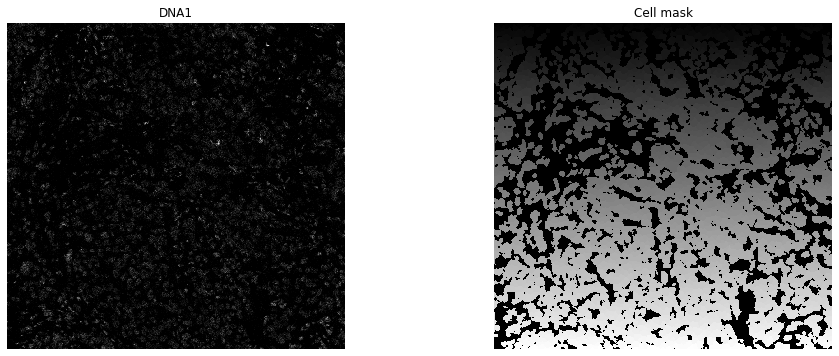

```python
target = 'DNA1'

fig, axs = plt.subplots(ncols=2, figsize=(16, 6))
channel = panel.loc[panel['target'] == target, 'channel'].iloc[0]
axs[0].imshow(img[channel], cmap=plt.cm.gray)
axs[0].set_title(target)
axs[0].axis('off')
axs[1].imshow(mask, cmap=plt.cm.gray)
axs[1].set_title('Cell mask')
axs[1].axis('off')
plt.show()
```

## Quantify cells

```python
out_file_path = '../Data/jackson_fischer_nature_2020/BaselTMA_SP41_15.475kx12.665ky_10000x8500_5_20170905_122_166_X15Y4_231.csv'

mean_intensities = pd.DataFrame(columns=panel.target)
mean_intensities.index.name = 'cell_id'
for cell_id in np.unique(mask[mask > 0]):
    mean_intensities.loc[cell_id] = img[:, mask == cell_id].mean(axis=1)
mean_intensities.to_csv(out_file_path)
mean_intensities
```

| target cell_id | H3tot | H3met | CK5 | Fibronectin | CK19 | CK8/18 | TWIST1 | CD68 | CK14 | SMA | ... | EGFR | S6 | Sox9 | vWf_CD31 | mTOR | CK7 | panCK | cPARP_cCasp3 | DNA1 | DNA2 |
| --- | --- | --- | --- | --- | --- | --- | --- | --- | --- | --- | --- | --- | --- | --- | --- | --- | --- | --- | --- | --- | --- |
| 1 | 11.435987 | 1.280221 | 0.092805 | 0.443909 | 1.151130 | 1.619805 | 0.099519 | 0.074831 | 0.050494 | 0.203844 | ... | 0.156558 | 2.300416 | 0.126442 | 0.114558 | 0.922130 | 0.460403 | 11.155493 | 0.821286 | 7.141858 | 13.127857 |
| 2 | 6.676378 | 0.898793 | 0.116354 | 1.181683 | 3.479732 | 2.860988 | 0.181878 | 0.385378 | 0.099049 | 2.650049 | ... | 0.471000 | 2.454634 | 0.076024 | 0.069695 | 1.408488 | 0.940549 | 28.769440 | 1.303585 | 2.372439 | 4.156317 |
| 3 | 5.500190 | 0.693690 | 0.108095 | 0.713952 | 1.226667 | 2.668619 | 0.047619 | 0.201976 | 0.047619 | 0.786857 | ... | 0.189405 | 2.120524 | 0.048429 | 0.087429 | 0.856952 | 0.399071 | 21.614906 | 1.032905 | 1.630524 | 3.740691 |
| 4 | 5.994712 | 0.589423 | 0.341192 | 1.112769 | 0.660231 | 0.937135 | 0.086615 | 0.275154 | 0.038462 | 6.223981 | ... | 0.097115 | 1.271404 | 0.143654 | 0.057692 | 0.465808 | 0.416808 | 13.019441 | 0.625423 | 1.114288 | 2.582231 |
| 5 | 4.390930 | 0.447153 | 0.123306 | 8.072971 | 0.268361 | 0.091111 | 0.027778 | 1.271486 | 0.057403 | 0.171264 | ... | 0.175153 | 1.790347 | 0.305681 | 0.069625 | 0.406875 | 0.000000 | 0.066417 | 0.702208 | 1.957056 | 3.781848 |
| ... | ... | ... | ... | ... | ... | ... | ... | ... | ... | ... | ... | ... | ... | ... | ... | ... | ... | ... | ... | ... | ... |
| 3064 | 6.344487 | 0.825559 | 0.266504 | 2.651513 | 1.203252 | 3.964712 | 0.294982 | 0.443207 | 0.109324 | 8.737261 | ... | 0.470577 | 2.529396 | 0.679540 | 0.112162 | 2.999352 | 0.472649 | 14.226991 | 0.971306 | 1.405333 | 2.625270 |
| 3065 | 6.993988 | 0.646197 | 0.052889 | 2.900827 | 0.486395 | 3.165371 | 0.161827 | 0.522815 | 0.162383 | 4.527260 | ... | 0.374506 | 2.370037 | 0.412938 | 0.155000 | 1.422000 | 0.292173 | 11.051740 | 1.097259 | 1.936333 | 3.482408 |
| 3066 | 9.688334 | 0.688815 | 0.147556 | 9.493247 | 0.240259 | 0.141160 | 0.110457 | 0.249543 | 0.038679 | 4.003494 | ... | 0.230432 | 1.227074 | 0.069160 | 0.078691 | 0.388420 | 0.017420 | 0.321136 | 0.304716 | 4.284889 | 8.294691 |
| 3067 | 10.906000 | 0.491817 | 0.070133 | 1.354333 | 0.231033 | 0.430583 | 0.095433 | 0.136617 | 0.024117 | 0.424767 | ... | 0.165233 | 1.184783 | 0.028350 | 0.059033 | 0.350483 | 0.111883 | 1.587350 | 0.468950 | 2.887600 | 5.298084 |
| 3068 | 9.014727 | 1.090788 | 0.127515 | 6.564909 | 0.219364 | 0.385364 | 0.097606 | 0.412667 | 0.090909 | 2.362424 | ... | 0.200818 | 1.223242 | 0.214333 | 0.461303 | 0.514970 | 0.000000 | 0.841606 | 0.417091 | 3.045879 | 4.926606 |

3066 rows × 39 columns

## Single-cell analysis

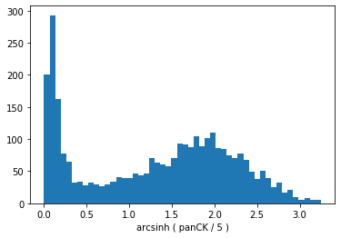

```python
panCK_transformed = np.arcsinh(mean_intensities['panCK'] / 5)

plt.hist(panCK_transformed, bins=50)
plt.xlabel('arcsinh ( panCK / 5 )')
plt.show()
```

```python
from sklearn.mixture import GaussianMixture

gmm = GaussianMixture(n_components=2, tol=1e-9, verbose=2)
predictions = gmm.fit_predict(panCK_transformed[:, None])
probabilities = gmm.predict_proba(panCK_transformed[:, None])
```

```
Initialization 0
  Iteration 10	 time lapse 0.01065s	 ll change 0.00965
  Iteration 20	 time lapse 0.00723s	 ll change 0.00003
  Iteration 30	 time lapse 0.00722s	 ll change 0.00000
  Iteration 40	 time lapse 0.00727s	 ll change 0.00000
  Iteration 50	 time lapse 0.00720s	 ll change 0.00000
Initialization converged: True	 time lapse 0.03961s	 ll -0.96420
```

```python
panCK_positive_class = gmm.means_.argmax()
n_panCK_negative = np.sum(predictions != panCK_positive_class)
n_panCK_positive = np.sum(predictions == panCK_positive_class)
```

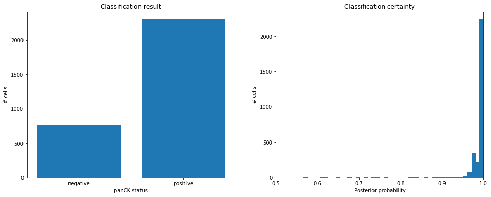

```python
fig, axs = plt.subplots(ncols=2, figsize=(16, 6))

axs[0].bar(['negative', 'positive'], [n_panCK_negative, n_panCK_positive])
axs[0].set_title('Classification result')
axs[0].set_xlabel('panCK status')
axs[0].set_ylabel('# cells')

axs[1].hist(probabilities.max(axis=1), bins=50)
axs[1].set_title('Classification certainty')
axs[1].set_xlabel('Posterior probability')
axs[1].set_ylabel('# cells')
axs[1].set_xlim(0.5, 1)

plt.show()
```

# Practice material

This session: slides & video recording

BIO134 Open edX course: Python for Biologists; all weeks

Online Python challenge platforms, e.g. https://edabit.com/challenges/python3

Online book for reference: http://openbookproject.net/thinkcs/python/english3e

Numpy exercises: https://www.w3resource.com/python-exercises/numpy/  
Matplotlib exercises: https://www.w3resource.com/graphics/matplotlib/  
Pandas exercises: https://www.w3resource.com/python-exercises/pandas/

# Outlook

**April 14**: version control with Git

Next Python session: "practice time"

- Integrated development environments
- Package management with pip and conda
- Q&A, code review, ...

Potential future topics:

- Code organization
- Documentation & testing
- Containerization & deployment
- Pipeline building with `nextflow` `snakemake` `luigi` ...
- Relational databases with `sqlalchemy`
- Machine learning with `scikit-learn`
- Deep learning with `pytorch`
- GUI development with `pyqt`
- ... let me know :-)